# Making a Venn diagram

In this notebook, I will demonstrate how to make a Venn diagram that compares enrichment detection between methods. This relies on two functions from the $\texttt{functions.R}$ file:

- $\texttt{simulate_data}$, from which we simulate data according to Section 6.1.
- $\texttt{simulate_pathways}$, from which we simulate pathways with genes that only correspond to false hypotheses by setting TDP = 1.

The plot at the end of this notebook will be similar to the one shown in the faceted plot of Figure 11 for pathway size = 5 and $\rho = 0.7$. By changing the values in $\texttt{simulate_data}$ and $\texttt{simulate_pathways}$ accordingly, one can make the other plots as well.

We first calculate the power for each method using the following code:

```
source("functions.R")
set.seed(54483901)

df <- simulate_data(n = 1000, pi1 = 0.8, rho = 0.7, signal = 4, df = 2)
# Here, m = number of pathways, and n = pathway size
paths <- simulate_pathways(df, m = 1000, n = 5, TDP = 1)

res_eBH <- res_BY <- res_Su <- res_TDP <- logical(1000)

for (i in seq_len(1000)) {
  in_path <- df$gene_id %in% paths[[i]]
  res_eBH[i] <- closedeBH(calibrator_BY(df$pvalue, 0.05), in_path)
  res_BY[i]  <- closedBY(df$pvalue, in_path)
  res_Su[i]  <- closedSu(df$pvalue, in_path)
  res_TDP[i] <- setTest(df$pvalue, df$gene_id, set = paths[[i]],
                        testype = "competitive", testvalue = 0.8) < 0.05
}
```

We can then convert the results into a Venn diagram using the $\texttt{ggplot2}$ and $\texttt{ggVennDiagram}$ libraries:

```
library(ggplot2)
library(ggVennDiagram)

label_exprs <- c(
  'bar("BY")',
  'bar("e-BH")',
  'bar("Su")',
  'paste(bold("p")["comp"])'
)

ellipses <- setNames(
  list(which(res_BY), which(res_eBH), which(res_Su), which(res_TDP)), label_exprs
)

p <- ggVennDiagram(ellipses, label = "count", set_size = 4, label_size = 4,
                     edge_size = 0.4) +
    scale_fill_gradient(low = "white", high = "#648FFF") +
    theme(legend.position = "none")

idx <- which(sapply(p$layers, function(l) {
  inherits(l$geom, "GeomText") && "name" %in% names(l$data)
}))

p$layers[[idx]]$geom_params$parse <- TRUE

p
```

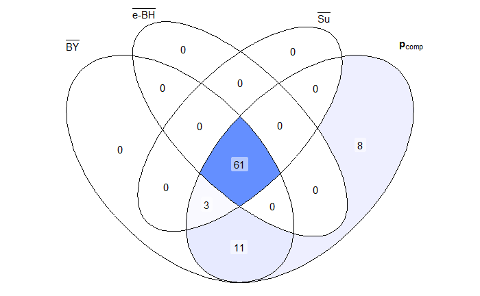

**Note:** I used the $\texttt{wrap_plots}$ function from the $\texttt{patchwork}$ library to create the faceted plot of Figure 11. The code that I wrote for this is mostly similar to the code above, with the key difference being that I used a nested for-loop to repeat everything for all combinations of pathway sizes and $\rho$. In addition, there are some visual differences between this Venn diagram and those shown in Figure 11. Applying these changes results in code that is very lengthy, unintuitive, and not very interesting to the reader. For this reason, I decided to only demonstrate how to make a single Venn diagram.